# Creating a Milk Model

Ryan Greenup

25 March 2018

#Preamble First as a matter of housekeeping, we need to load in pertinent packages and set the working directory

```r
# Load Packages -----------------------------------------------------------

if(require('pacman')){
  library('pacman')
}else{
  install.packages('pacman')
  library('pacman')
}
```

```r
pacman::p_load(xts, sp, gstat, ggplot2, rmarkdown, reshape2, ggmap,
               parallel, dplyr, plotly)


# Set the Working Directory -----------------------------------------------

set_wd <- function() {

  #Install the RStudio API package

  if(require('rstudioapi')){
    library('rstudioapi')
  }else{
    install.packages('rstudioapi')
    library('rstudioapi')
  }

  #Use the Rstudio API to get the working directory

  current_path <- getActiveDocumentContext()$path
  setwd(dirname(current_path ))
  print( getwd() )
}

#set_wd()

# Import the Data Set -----------------------------------------------------
milk.df <- read.csv("milk.csv", header = TRUE, sep = ",")
head(milk.df)
```

```
##   Month Production
## 1     1        589
## 2     2        561
## 3     3        640
## 4     4        656
## 5     5        727
## 6     6        697
```

```r
    ##Create Assignments
    month <- milk.df$Month
    prod  <- milk.df$Production

    milk.lm <- lm(prod ~ month)
```

#Inspect the Data Set So first we’ll look at what our data consists of:

```r
head(milk.df)
```

```
##   Month Production
## 1     1        589
## 2     2        561
## 3     3        640
## 4     4        656
## 5     5        727
## 6     6        697
```

Now we will make a quick plot of the data

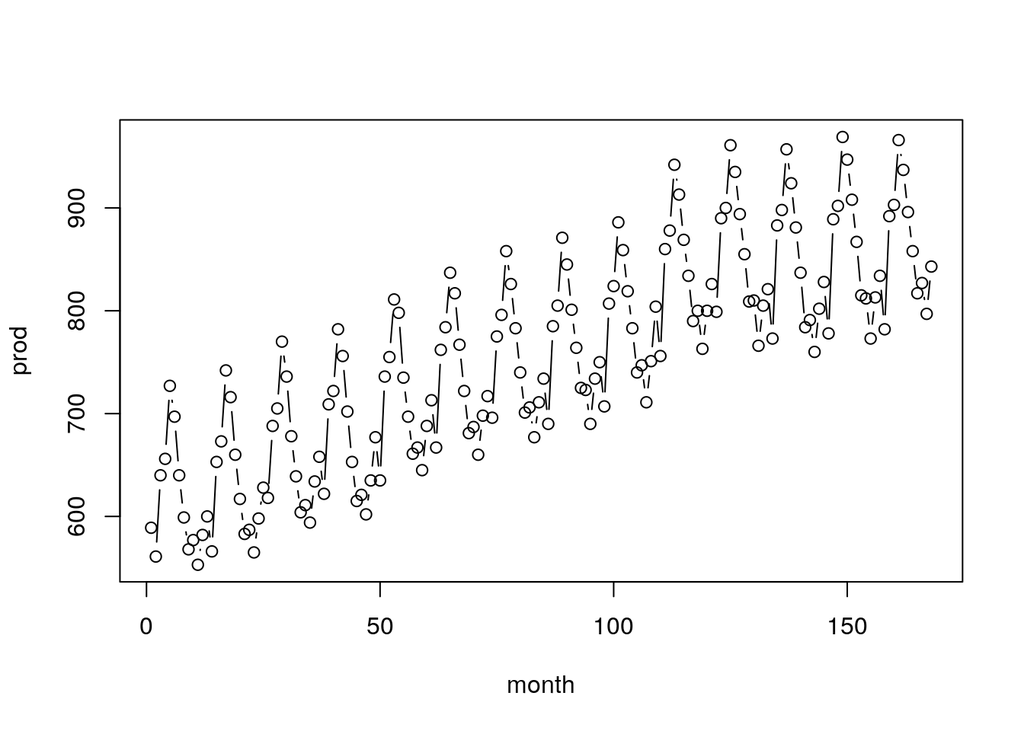

```r
plot(x = month, y = prod, lty = 1, type = "b")
```

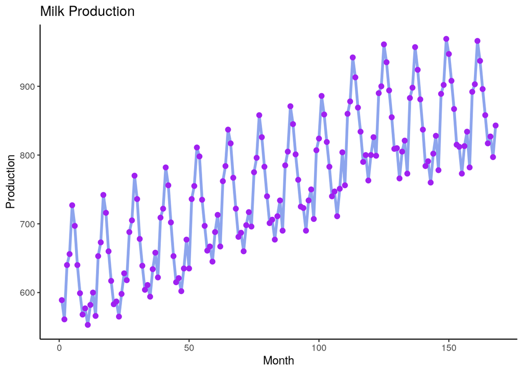

```r
    ggplot(data = milk.df, aes(x = Month, y = Production)) +
      geom_line(col = "Royalblue", lwd = 1.25, alpha = 0.6) +
      theme_classic() +
      ggtitle("Milk Production") +
      geom_point(col = "purple", lwd = 2)
```

#Create a Model This model has a positive linear trend and appears to be seasonal, perhaps an ARIMA model would be appropriate, but for the time being, we will fit a linear trigonometric plot:

```r
# Create Linear Model -----------------------------------------------------

milk.lmtrig <- lm(prod ~ month + I(sin(2*pi*month/12)) + I(cos(2*pi*month/12)))
```

Consider the resudiuals of the model:

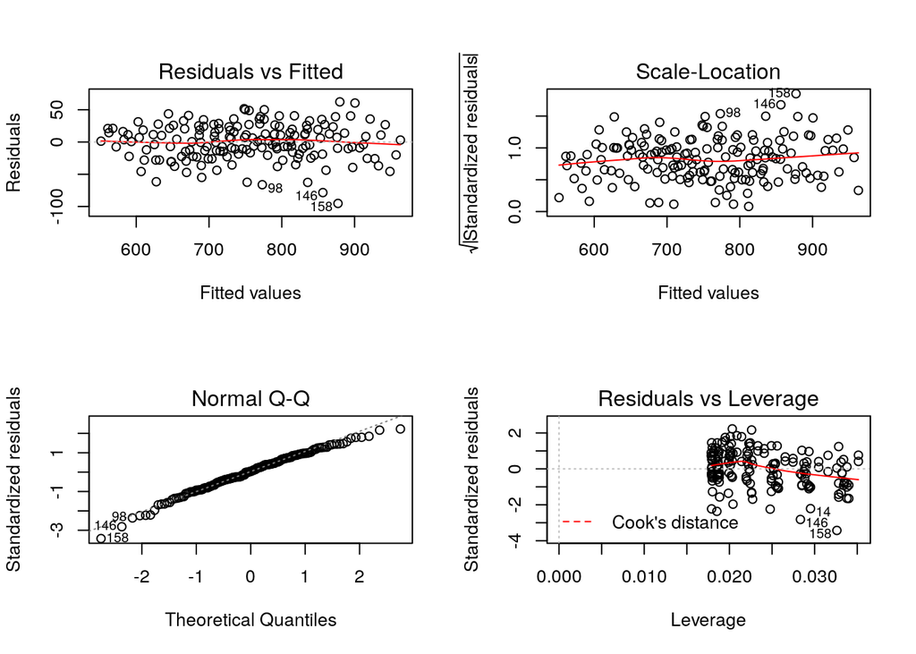

```r
layout(matrix(nrow = 2, 1:4))
plot(milk.lmtrig)
```

These residuals are normally distributed, thus their is no cause to discard the model.

```r
summary(milk.lmtrig)
```

```
##
## Call:
## lm(formula = prod ~ month + I(sin(2 * pi * month/12)) + I(cos(2 *
##     pi * month/12)))
##
## Residuals:
##     Min      1Q  Median      3Q     Max
## -95.212 -18.636   1.025  20.462  62.270
##
## Coefficients:
##                           Estimate Std. Error t value Pr(>|t|)
## (Intercept)                608.213      4.383  138.77   <2e-16 ***
## month                        1.734      0.045   38.52   <2e-16 ***
## I(sin(2 * pi * month/12))   33.544      3.086   10.87   <2e-16 ***
## I(cos(2 * pi * month/12))  -67.943      3.082  -22.05   <2e-16 ***
## ---
## Signif. codes:  0 '***' 0.001 '**' 0.01 '*' 0.05 '.' 0.1 ' ' 1
##
## Residual standard error: 28.24 on 164 degrees of freedom
## Multiple R-squared:  0.925,  Adjusted R-squared:  0.9236
## F-statistic: 674.3 on 3 and 164 DF,  p-value: < 2.2e-16
```

#Plot the Model In order to plot this model we will have to predict for it’s values over a data frame

```r
  #In order to plot this model, we need to use it to predict
  #over a data frame
    x.pred <- 1:length(month)
    y.pred <- predict(milk.lmtrig, data.frame(month = x.pred))
    milk.mod <- data.frame("Month" = x.pred, "Production" = y.pred)
```

Now we can make plots for this model to contrast it to the original:

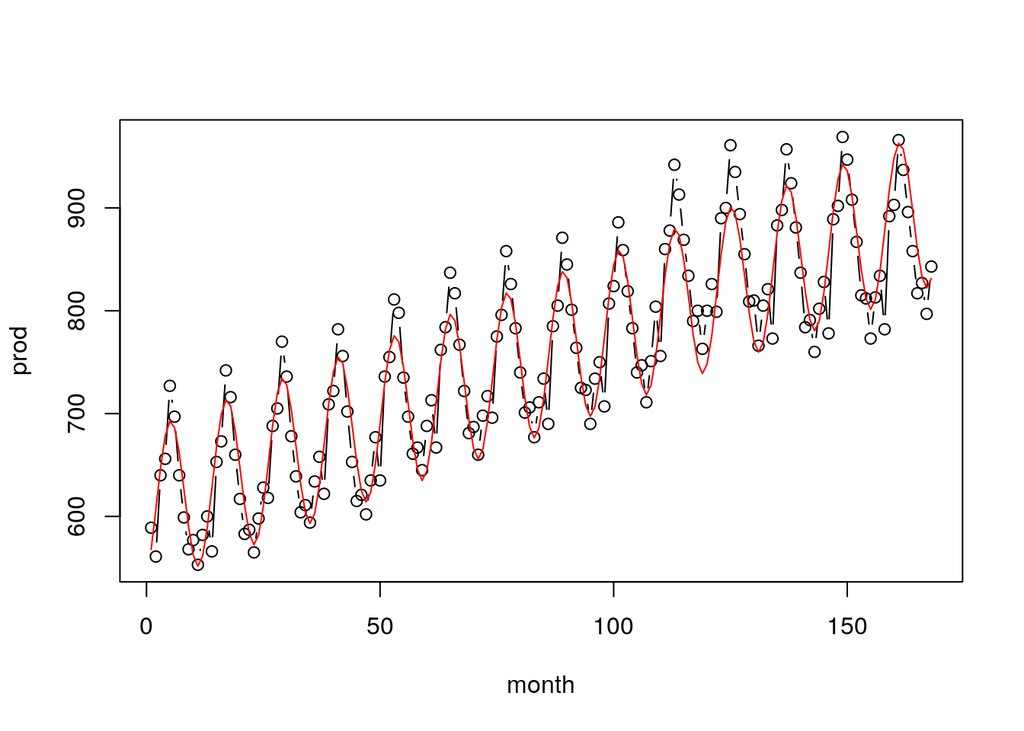

```r
#Plot the Prediction over the initial plot

      #Base Plot
      plot(x = month, y = prod, lty = 1, type = "b")
      lines(x = milk.mod$Month, y = milk.mod$Production, col = "red")
```

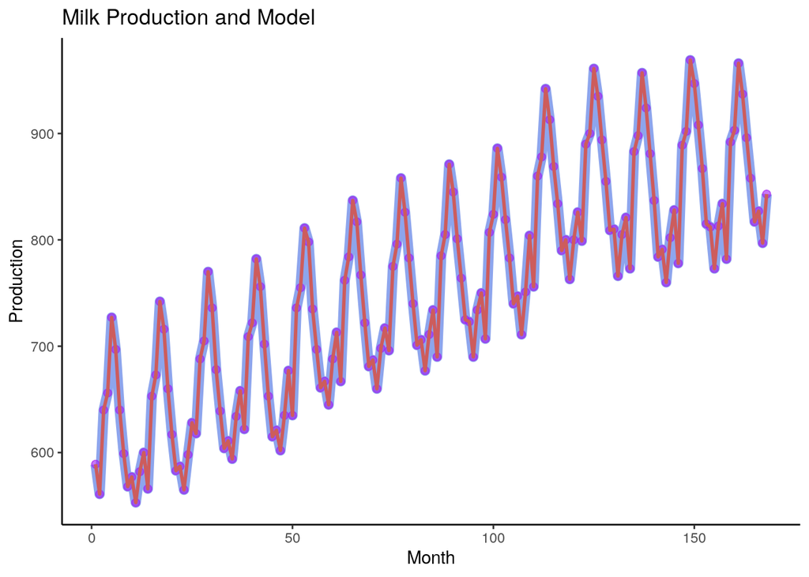

```r
      #ggplot2
      ggplot(data = milk.df, aes(x = Month, y = Production)) +
        geom_line(col = "Royalblue", lwd = 3, alpha = 0.6) +
        theme_classic() +
        ggtitle("Milk Production and Model") +
        geom_point(col = "purple", lwd = 2, alpha = 0.6) +
        #add in the model
        geom_line(col = "Indianred", lwd = 1)
```

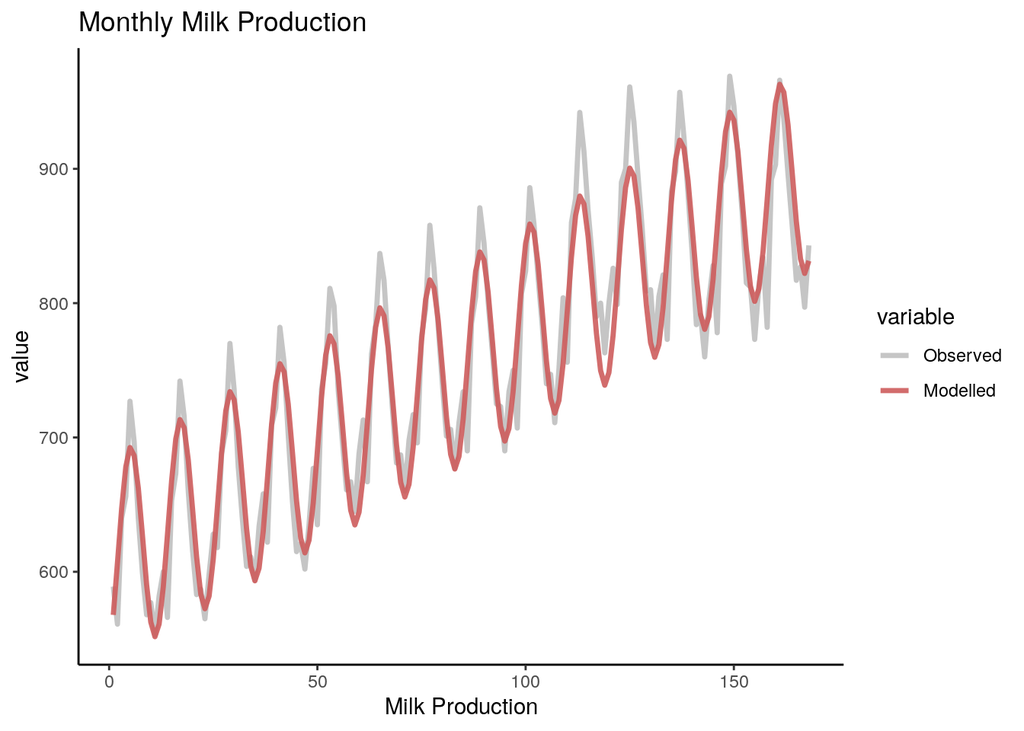

```r
        ##ggplot2 melted
        milk.df.fin <- data.frame("Month" = month,
                                  "Observed" = prod,
                                  "Modelled" = milk.mod$Production)
        milk.df.fin.melt <- melt(milk.df.fin, id = "Month")
        ggplot(data = milk.df.fin.melt, aes(x = Month,
                                            y = value,
                                            col = variable)) +
          geom_line(lwd = 1.2, alpha = 0.9) +
          theme_classic() +
          ggtitle("Monthly Milk Production") +
          xlab("Milk Production") +
          scale_color_manual(values = c('Observed' = 'grey',
                                        'Modelled' = 'indianred'))
```

#Conclusion A trigonometric linear model appears to fit the seasonal data reasonably well both by looking at the plots and the residual distribution